# アラーム疲労解析 概要レポート

公開

2026年3月9日

# Phase 1: 基礎構造の把握

観察期間：2025年7月15日〜9月9日（57日間）、西10・西11病棟のセントラルモニタアラームログを対象とした。

## 1. データ概要

| 項目 | 値 |
| --- | --- |
| 観察期間（日数） | 57日 |
| 総アラーム件数 | 193,852 |
| 1日あたり中央値 [IQR] | 2936 [2032.25–3902.5] |
| ADVISORY件数（割合） | 135783 (70%) |
| WARNING件数（割合） | 57847 (29.8%) |
| CRISIS件数（割合） | 222 (0.1%) |
| duration_zero件数（割合） | 28643 (14.8%) |
| duration_long件数（割合） | 1163 (0.6%) |

## 2. アラーム種別の構造

### 主要アラーム内容（上位5件 × 分類）

[output not shown]

### 時間帯別アラーム件数（技術的 vs 臨床的）

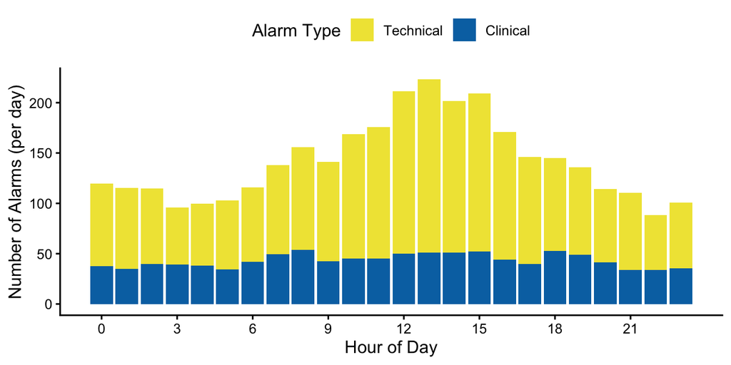

図 1: 時間帯別アラーム件数（臨床的 vs 技術的）。観察期間57日間の1日平均件数を時間帯別に示す。

## 3. 時間的曝露パターン

### 曜日別アラーム件数

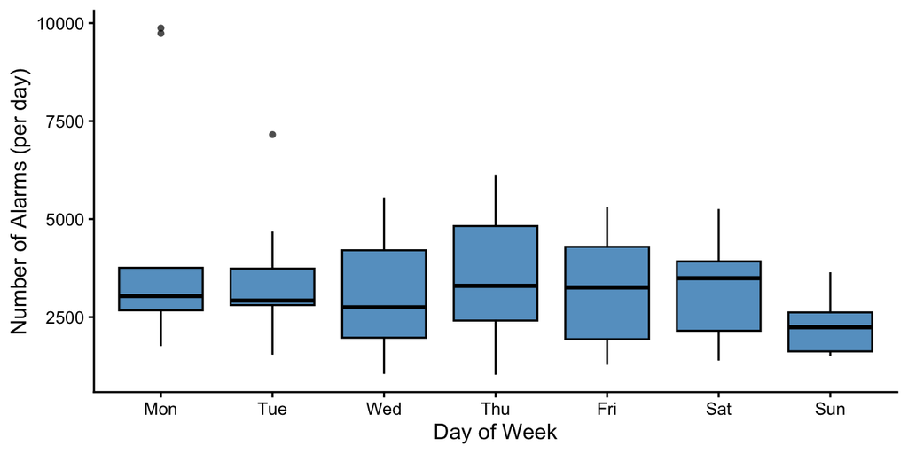

図 2: 曜日別アラーム件数（箱ひげ図）。1日あたりの総アラーム件数の分布を曜日別に示す。

### 時間帯×曜日ヒートマップ（臨床的アラーム・優先度別）

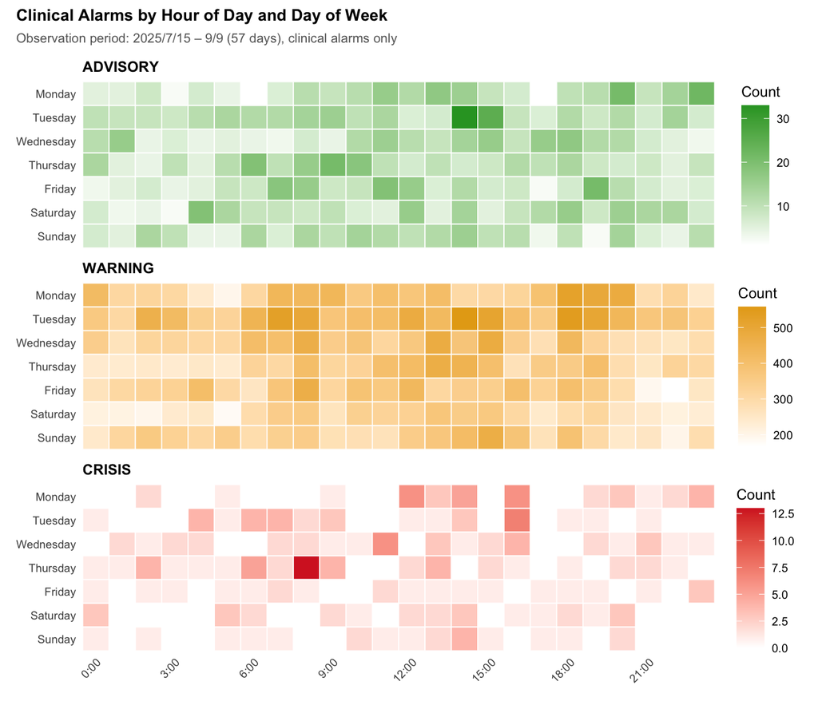

図 3: 臨床的アラームの時間帯×曜日ヒートマップ（優先度別）。観察期間57日間の累積件数を示す。

## 4. 看護師反応の実態

### 分類×優先度別 消音率・反応時間（duration ≥ 30秒）

| 分類 | 優先度 | 件数 | 消音あり | 消音率 (%) | 反応時間中央値 (秒) |
| --- | --- | --- | --- | --- | --- |
| 臨床的 | ADVISORY | 118 | 21 | 17.8 | 192 |
| 臨床的 | WARNING | 10,754 | 2,695 | 25.1 | 31 |
| 臨床的 | CRISIS | 115 | 107 | 93.0 | 9 |
| 技術的 | ADVISORY | 22,490 | 603 | 2.7 | 1090 |
| 技術的 | WARNING | 337 | 132 | 39.2 | 195.5 |

> **注**: `duration ≥ 30秒` のアラームのみを対象とした。反応時間は看護師が消音ボタンを押すまでの秒数（消音ありのみ）。

### 臨床的アラームの持続時間分布（消音あり vs なし）

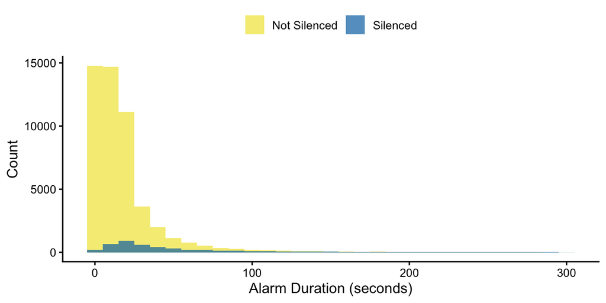

図 4: 臨床的アラームの持続時間分布（消音あり vs なし）。1〜300秒の範囲を表示。

## 5. ゾーン別アラーム分布

高重症ゾーン（12床：1101-A〜E, Re-A/B, W10-01〜05）と一般ゾーン（29床）に分けて臨床的アラームの時間帯・曜日パターンを比較した。

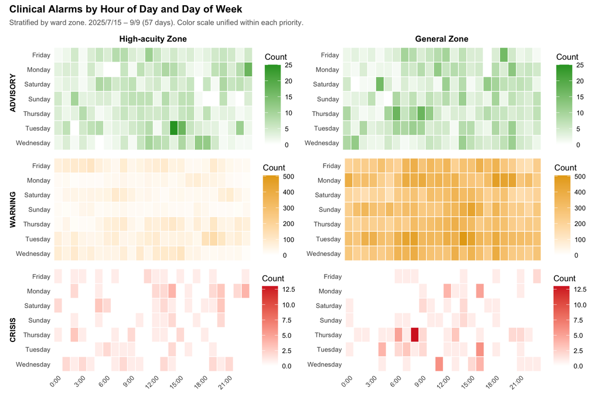

図 5: 臨床的アラームのゾーン別・時間帯×曜日ヒートマップ。同一優先度内でカラースケールを統一して比較可能にしている。

## 6. Phase 1 まとめと課題

### 主な発見

- 技術的アラームが全体の **69.5%**（うちSpO2プローブ確認だけで48%）を占め、看護師にほぼ無視されている（消音率 0.7%）
- 臨床的アラームの消音率は優先度に大きく依存：ADVISORY 17.8%、WARNING 25.1%、CRISIS 93%
- CRISISアラームへの反応時間中央値は **9秒** と迅速だが、WARNINGは **31秒**
- 消音ありアラームの持続時間中央値（36秒）は消音なし（10秒）より長く、短時間での自然終了が「無反応」の多くを説明する可能性がある

### 解釈上の限界

- `silenced`（消音）は「臨床的対応」と「とりあえず消音」を区別できない
- `response_sec` も「ボタン押下時間」であり、患者評価までの時間ではない
- アラームログ単体で「臨床的に有害な無反応」を直接証明することは困難

### 個人メモ、20260309クオリティ相談しての追加検討事項（北村先生、新開師長）

- 重症度、反応時間を分けてみてみる。さらにそれを時間帯ごとに反応時間を見てみる。
- 看護師も−22時までは仮眠にいっていない。それ以降は人数が減るから反応時間が変わるはず（予想）。
- 勝手に消えているアラームはなにかを可視化する。
- **パラメータごとの消去時間と消去率**→これこそ看護師の直感じゃない？

## 7. パラメータ別消去率・消去時間

各アラームパラメータ（内容１）× 優先度 × 分類ごとに、消去率・消去時間中央値・高重症ゾーン由来割合を集計した（n ≥ 10 のみ）。

| 内容１ | 優先度 | 分類 | 件数 | 消去あり | 消去率 (%) | 消去時間中央値 (秒) | duration中央値 (秒) | 高重症割合 (%) |
| --- | --- | --- | --- | --- | --- | --- | --- | --- |
| ASYSTOLE | CRISIS | 臨床的 | 44 | 41 | 93.2 | 7 | 45.0 | 25.0 |
| V. FIB | CRISIS | 臨床的 | 109 | 87 | 79.8 | 8 | 34.0 | 37.6 |
| NIBP (S) | WARNING | 臨床的 | 426 | 287 | 67.4 | 21 | 21.5 | 70.7 |
| V. TACHY | CRISIS | 臨床的 | 69 | 30 | 43.5 | 8 | 11.0 | 76.8 |
| 電波切れ | WARNING | 技術的 | 364 | 152 | 41.8 | 130 | 120.0 | 0.0 |
| SpO2 | ADVISORY | 臨床的 | 23 | 6 | 26.1 | 195.5 | 1468.0 | 100.0 |
| NIBP | ADVISORY | 臨床的 | 46 | 10 | 21.7 | 195.5 | 523.5 | 84.8 |
| BRADYCARDIA | WARNING | 臨床的 | 979 | 133 | 13.6 | 16 | 21.0 | 15.3 |
| TACHYCARDIA | WARNING | 臨床的 | 8,022 | 1,034 | 12.9 | 21 | 23.5 | 17.3 |
| NIBP | ADVISORY | 技術的 | 152 | 16 | 10.5 | 3444 | 3488.5 | 95.4 |
| RR (APNEA) | WARNING | 臨床的 | 1,496 | 112 | 7.5 | 15 | 7.0 | 57.3 |
| 解析不能 | WARNING | 技術的 | 241 | 17 | 7.1 | 17 | 8.0 | 26.6 |
| SpO2 | WARNING | 臨床的 | 44,413 | 3,034 | 6.8 | 18 | 9.0 | 11.3 |
| VPC RUN | ADVISORY | 臨床的 | 1,574 | 44 | 2.8 | 16.5 | 14.0 | 44.7 |
| 電極確認 | ADVISORY | 技術的 | 22,696 | 439 | 1.9 | 2586 | 4.0 | 9.7 |
| PR (SpO2) | WARNING | 臨床的 | 1,900 | 23 | 1.2 | 9 | 3.0 | 23.1 |
| SpO2 | ADVISORY | 技術的 | 94,477 | 285 | 0.3 | 15 | 6.0 | 6.2 |
| 電波切れ | ADVISORY | 技術的 | 16,809 | 5 | 0.0 | 5 | 2.0 | 0.0 |

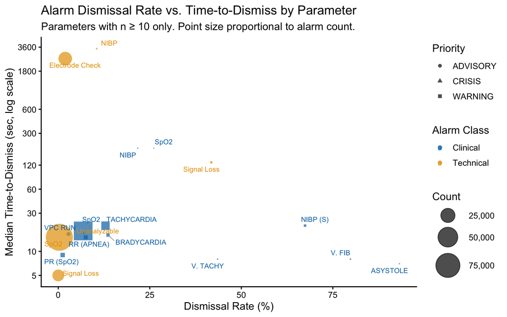

図 6: パラメータ別消去率・消去時間散布図。Y軸は対数スケール。色は分類（臨床的／技術的）、形は優先度を示す。